# Project2

Zihan LI (24049427), Baoyue ZHANG (23967286)

2023-09-23

- 0. Preparation Work
  - 0.1 Define the Goal
  - 0.2 Load Libraries and Data
  - 0.3 choose response
    - Binaryization thinking
    - Linear Regression Analysis and Important Outputs
  - 0.4 External Dataset
  - 0.5 Literature Review
  - 0.6 split data
  - 0.7 Self-defined Function
- 1.Data Preparation
  - 1.0 Pipline
  - 1.1 Subset and Merge,add Source Data
  - 1.2 Data Cleaning
- 2. Classification
  - 2.0 feature selection
    - Deviance-Based Feature Selection
    - Random Forest-Based Feature Selection
  - 2.1 Logistic regression
  - 2.2 Decision Tree
  - 2.4 SVM & LIME
  - 2.5 Model Comparison on Validation Data
  - 2.6 Performance Evaluation on Test Data
    - ROC Curve Comparison
    - Confusion Matrix Comparison
- 3. Clustering
  - 3.1 Scaling
  - 3.2 Hierarchical Clustering
    - Visualsation
    - Evaluation
  - 3.3 K-means
    - Choosing an Appropriate K Value:
- 4. Shiny App
- 5. Reference

Zihan Li (24049427) （50%）：all tasks  
Baoyue Zhang (23967286) (50%): all tasks

[My Shiny APP Youtube URL](https://youtu.be/eOiH2xxQIFU)

# 0. Preparation Work

## 0.1 Define the Goal

**We want to learn what factors directly or indirectly influence the level of YouTuber’s earnings.**

By processing the original youTube dataset purposefully and left joining other dataset with extra factors, such as viewer engagement, building and evaluating models, we would be able to present some meaningful results.

## 0.2 Load Libraries and Data

```r
suppressMessages(library(tidyverse))
suppressMessages(library(shiny))
suppressMessages(library(knitr))
suppressMessages(library(formattable))
suppressMessages(library(crayon))
suppressMessages(library(gridExtra))
suppressMessages(library(kableExtra))
suppressMessages(library(pander))
suppressMessages(library(lime))
suppressMessages(library(caret))
suppressMessages(library(vtreat))
suppressMessages(library(caTools))
suppressMessages(library(e1071))
suppressMessages(library(randomForest))
suppressMessages(library(ggmice))
suppressMessages(library(shinythemes))
suppressMessages(library(DALEX))
suppressMessages(library(pROC))
```

```r
data_path <- "Global\ YouTube\ Statistics.csv"
df <- read.csv(data_path)
ytb <- df
```

## 0.3 choose response

### Binaryization thinking

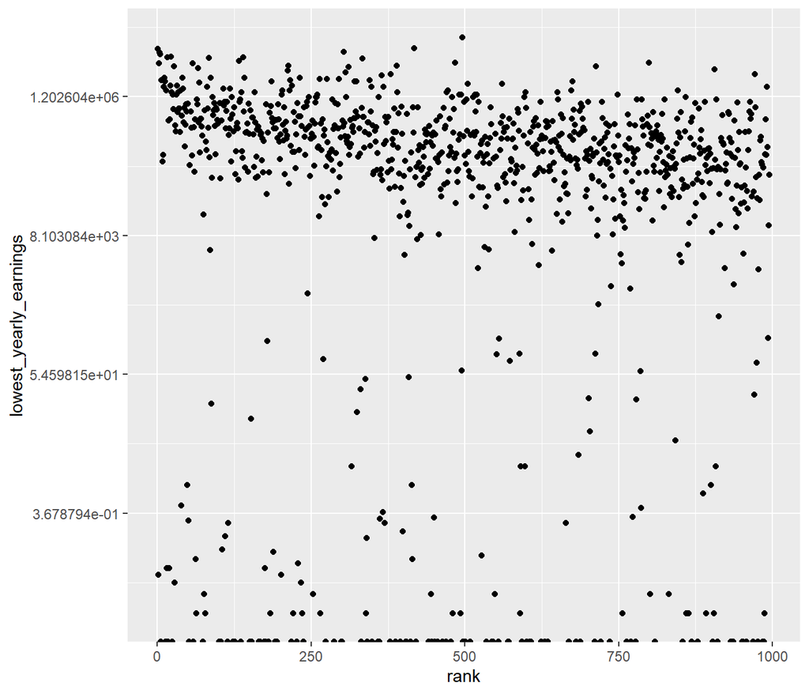

```r
ggplot(df, aes(x = rank, y = lowest_yearly_earnings)) +
  geom_point() +
  scale_y_continuous(trans = "log")
```

Based on a lot of visualization works, we found that the `earning` data is highly unevenly distributed and hard to find the right thresholds. Visually, these data points can be divided into two piles. Most of data points are fall into higher levels, and another pile is channels with extremely low earnings.

This could cause problems when we turn the response variable into binary. If we just choose a threshold based on earning’s distribution, then this variables are uneven, potentially causing poor performance of our models. On the other hand, If we choose median or mean value would directly cut off the high earnings pile, Conflicting with the high-and-low-income business logic. And there is no general criteria for youTube channel’s earning division. It’s a dilemma to find the right threshold.

So hopefully we would expect the machine learning classification models would have a good result in later works.

### Linear Regression Analysis and Important Outputs

Building on previous visualization work, we have learned that there is some linear correlation between `earnings` and the last 30 days `views`, so we first build an LM model to confirm this relationship.

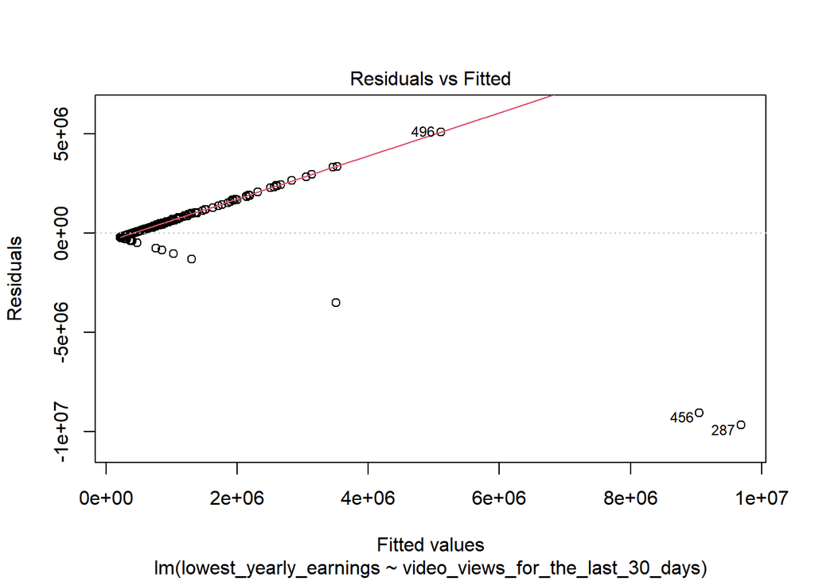

```r
lm_view_earning <- lm(lowest_yearly_earnings  ~ video_views_for_the_last_30_days, data = df)

# Visualize residuals vs. fitted values
plot(lm_view_earning, which = 1)
```

Such as [Social Blade](https://socialblade.com/youtube/youtube-money-calculator)is a website which is **YouTube certified** tracking user statistics for YouTube. According to its calculator, estimated daily earnings = daily views/1000 * estimated CPM (Note: The accepted formula that Social Blade LLC uses to calculate the CPM range is $0.25 USD - $4.00 USD.) “CPM, or cost per 1,000 impressions, is the cost an advertiser needs to pay on YouTube for every 1,000 impressions their ads receive on the video.” https://blog.hubspot.com/marketing/youtube-cpm

```r
daily_views <- df$video_views_for_the_last_30_days / 30

estimated_daily_earnings <- daily_views / 1000 * 0.25   # income calculator formula
matching_threshold <- 50

summary(abs(estimated_daily_earnings * 30 - df$lowest_monthly_earnings) <= matching_threshold)
```

```
##    Mode   FALSE    TRUE    NA's
## logical      29     910      56
```

```r
# same way we test the highest monthly earning
estimated_daily_earnings_highest <- daily_views / 1000 * 4
summary(abs(estimated_daily_earnings_highest * 30 - df$highest_monthly_earnings) <= matching_threshold)
```

```
##    Mode   FALSE    TRUE    NA's
## logical     173     766      56
```

The results highly match to our previous guess, except that the highest CPM limit may be slightly different. And it’s explainable, because many factors come into play when calculating a CPM. Quality of traffic, source country, niche type of video, price of specific ads, adblock, the actual click rate, etc. For the lowest earning on the other hand is the ad revenue that a youTuber will certainly receive.

Platforms like YouTube have witnessed notable changes in the number and nature of advertisements accompanying videos. Due to the revenue-sharing model based on advertisements, YouTuber have to increase its video view count.(Irshad, Anand, and Ram 2023)

As we understand earnings mainly come from advertisements, viewers engagements seem to be more important in terms of predicting earnings. Therefore we **might** need more information associated with those youTube channels.

## 0.4 External Dataset

We found this Top 1000 Youtubers statistics with youtube channel’s visits and likes information which are important indicators to reflect viewers engagements, therefore we join these datasets together using unique channel name and check the relationship between visits, likes and earnings.

Original link: [https://www.kaggle.com/datasets/computingvictor/top1000youtubers] [Download Dataset](https://www.kaggle.com/datasets/computingvictor/top1000youtubers/download?datasetVersionNumber=1)

```r
# Load top 1000 youtubers dataset
info <- read.csv("./youtubers_df.csv")

remove_invalid_characters <- function(text) {
  cleaned_text <-  str_replace_all(text, "[^[:alnum:]]", "")  # remove invalid characters and space
  return(tolower(cleaned_text))
}

ytb$Title <- sapply(ytb$Title, remove_invalid_characters)
info <- info[, c('Username', 'Visits','Likes')]
info$Username <- sapply(info$Username, remove_invalid_characters)
# left join original dataset with new data
y_withInfo <- merge(ytb, info, by.x="Title", by.y = "Username", all.x = TRUE, ignore.case = TRUE)
```

**Noted** Despite both are stats for the top 1,000 YouTubers, due to the two datasets grabbing different channel names, a lot of the rows don’t match, and the visits and likes columns have 400+ NAs. In order to reach the GOAL we still want to examine the relationship between the variables.

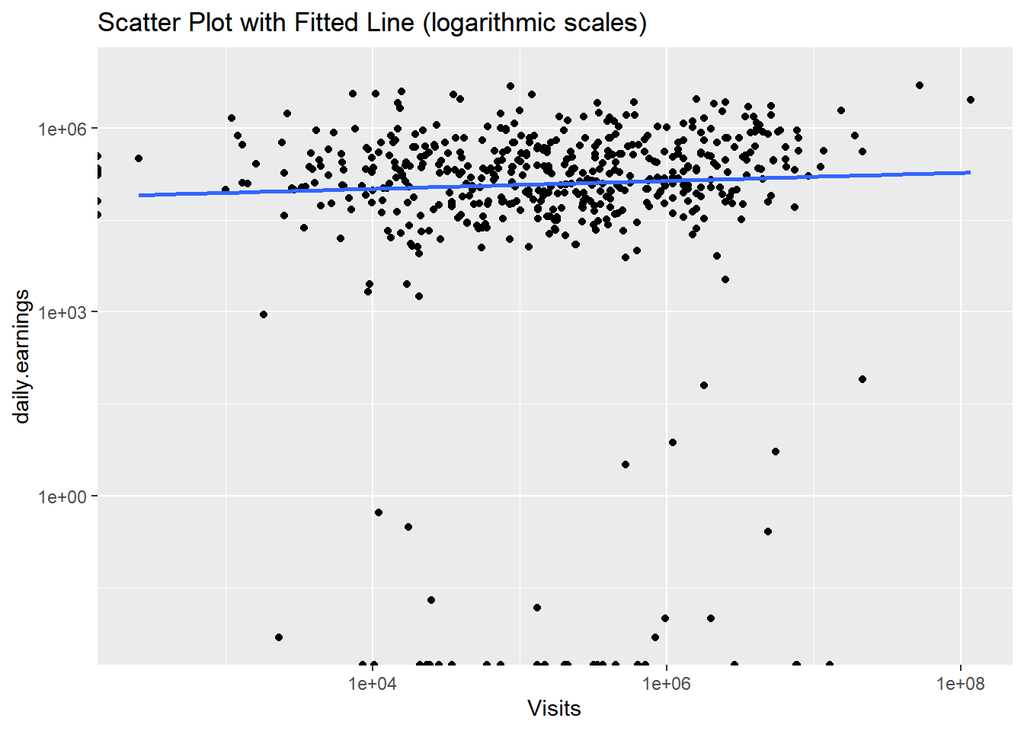

```r
y_new <- y_withInfo %>%

  select(Title, channel_type, subscribers, video.views, uploads, created_year, Visits, Likes) %>%
  mutate(
         daily.views = y_withInfo$video_views_for_the_last_30_days / 30,
         daily.earnings = (y_withInfo$lowest_monthly_earnings + y_withInfo$highest_monthly_earnings) / 2)
ggplot(data = y_new, aes(x = Visits, y = daily.earnings)) +
  geom_point() +  scale_x_log10() + scale_y_log10() +
  geom_smooth(method = "lm", formula = y ~ x, se = FALSE) +  # Fitted linear regression line
  labs(x = "Visits", y = "daily.earnings", title = "Scatter Plot with Fitted Line (logarithmic scales)")
```

Based on the plot, it doesn’t seem like there is any significant connection between these two variables. We need to test out using models.

```r
#  turn target variable into binary
choose_response <- function(data) {
  transformed_data <- data |>
    mutate(yearly_income = (highest_yearly_earnings + lowest_yearly_earnings) / 2) |>
    within({
      # income_cat
      income_cat <- NA
      income_cat[is.na(yearly_income)] <- 0
      income_cat[yearly_income <= 5e+06] <- 0
      income_cat[yearly_income > 5e+06] <- 1
      income_cat <- as.factor(income_cat)
    }) |>
    select(-lowest_monthly_earnings, -lowest_yearly_earnings, -highest_yearly_earnings, -highest_monthly_earnings, -yearly_income,-video_views_for_the_last_30_days)

  return(transformed_data)
}

y_test <- choose_response(y_withInfo)
```

```r
# create
eval_model <- function(model, data) {
  # Make predictions on the test set using the final model
  predictions <- predict(model, newdata = data)

  # Evaluate the final model
  conf_matrix <-confusionMatrix(predictions, data$income_cat)

  uc_value <- conf_matrix$byClass["ROC"]
  print(conf_matrix)
  #print(uc_value)
}
```

```r
y_test <- na.omit(y_test)
#summary(y_test$income_cat)
#lm_earning_visits <- glm(income_cat  ~ Visits, data = y_test)
#y_test$Visits <- as.factor(y_test$Visits)
#eval_model(lm_earning_visits, y_test)
#summary(lm)

library(caret)
library(rpart)
library(e1071)


logic_regression = train(income_cat ~ Visits, data = y_test,
                        method = "glm",family = "binomial")

summary(logic_regression)
```

```
##
## Call:
## NULL
##
## Coefficients:
##               Estimate Std. Error z value Pr(>|z|)
## (Intercept) -7.878e-01  1.224e-01  -6.438 1.21e-10 ***
## Visits       6.417e-08  3.586e-08   1.789   0.0735 .
## ---
## Signif. codes:  0 '***' 0.001 '**' 0.01 '*' 0.05 '.' 0.1 ' ' 1
##
## (Dispersion parameter for binomial family taken to be 1)
##
##     Null deviance: 454.47  on 356  degrees of freedom
## Residual deviance: 448.21  on 355  degrees of freedom
## AIC: 452.21
##
## Number of Fisher Scoring iterations: 5
```

```r
eval_model(logic_regression, y_test)
```

```
## Confusion Matrix and Statistics
##
##           Reference
## Prediction   0   1
##          0 236 115
##          1   2   4
##
##                Accuracy : 0.6723
##                  95% CI : (0.6209, 0.7208)
##     No Information Rate : 0.6667
##     P-Value [Acc > NIR] : 0.4355
##
##                   Kappa : 0.0331
##
##  Mcnemar's Test P-Value : <2e-16
##
##             Sensitivity : 0.99160
##             Specificity : 0.03361
##          Pos Pred Value : 0.67236
##          Neg Pred Value : 0.66667
##              Prevalence : 0.66667
##          Detection Rate : 0.66106
##    Detection Prevalence : 0.98319
##       Balanced Accuracy : 0.51261
##
##        'Positive' Class : 0
##
```

And There is only a modest reduction in deviance when comparing the null model to the model with the `Visits` predictor variable. This suggests that the `Visits` variable may not strongly improve the model’s fit compared to the null model.

```r
# Also test Likes variable
summary(train(income_cat ~ Likes, data = y_test,
                        method = "glm",family = "binomial"))
```

```
##
## Call:
## NULL
##
## Coefficients:
##               Estimate Std. Error z value Pr(>|z|)
## (Intercept) -7.388e-01  1.174e-01  -6.293 3.11e-10 ***
## Likes        6.510e-07  5.196e-07   1.253     0.21
## ---
## Signif. codes:  0 '***' 0.001 '**' 0.01 '*' 0.05 '.' 0.1 ' ' 1
##
## (Dispersion parameter for binomial family taken to be 1)
##
##     Null deviance: 454.47  on 356  degrees of freedom
## Residual deviance: 451.93  on 355  degrees of freedom
## AIC: 455.93
##
## Number of Fisher Scoring iterations: 4
```

Also, a modest reduction in deviance and a much higher p-value than 0.05 suggesting very weak evidence against the null hypothesis.

“It is widely recognized by statisticians, though not as widely by other researchers, that the p-value cannot be interpreted in isolation, but rather must be considered in the context of certain features of the design and substantive application, such as sample size and meaningful effect size”(Betensky 2019)

Therefore when we think of the NAs in our dataset and the specificity in the top 1000 youtube data (because there are a lot of celebrities and official channels in top 1000 and these channels are not really representative as samples to be analyzed).

**Based on above p-value, reduction in deviance and Context-Specific analysis, we decide not to choose the `Visits` and `Likes` as feature variables.**

## 0.5 Literature Review

Before starting feature selection process, we go through few literatures and documents about key factors may have a positive/negetive effect on youTube channel’s views as so to earnings. We found this article:

“For the multidimensional data analysis, the data retrieved from SocialBalde.com were converted into an OLAP data cube, and then Tableau Public was used. For each of the 1700 channels, we considered the number of videos uploaded, the number of subscribers and the number of views. These numerical dimensions were used to conduct a statistical analysis; more precisely, we determined the relative correlations between the above mentioned dimensions. Multidimensional data analysis refers to analyzing and categorizing data, based on multiple factors related to various entities, called dimensions. This method of analysis is an instrument used for different processes of mathematical modelling, with large and complex data. In this particular case, it provides insights across the gamut of YouTube channels.” (Lupu-Tătaru and Lixăndroiu 2022)

Here is the conclusion:

“In order to establish a profitable business, a social media entrepreneur needs an entertainment, travel or personal YouTube channel on which videos are constantly uploaded; their content should be perceived as engrossing by their subscribers. A profitable social media entrepreneur, in this case, is defined as somebody who is paid to advertise products or services or launches their own products or services. To obtain a large number of subscribers and views, interesting videos should be uploaded consistently and also with a proper description of the channel so that content can easily be found in the right category.” (Lupu-Tătaru and Lixăndroiu 2022)

Our interpretation: The factors mentioned in the article could be insightful for our future model building, but still this question we found earlier in the external dataset section – top 1000 dataset contains many celebrities and official channels, not just self start-up youTubers, whereas this article focuses on social media entrepreneurship. Under this conflicted context, we’ll only borrow slightly from this article and continue to choose the right variables in our own way.

## 0.6 split data

we will split our data into three sets: training, validation, and test - using training set for model training - the validation set is used to tune the model hyperparameters, and to evaluate the model performance (simulate the unseen testset during modeling) - the test set is used to evaluate the model performance for our final report of model performance

in this project, we will use 90/10 split for training and test set for now, we don’t need to use split the training data, because we will use cross-validation to tune the model hyperparameters

```r
choose_response <- function(data) {
  transformed_data <- data |>
    mutate(yearly_income = (highest_yearly_earnings + lowest_yearly_earnings) / 2) |>
    within({
      # income_cat
      income_cat <- NA
      income_cat[is.na(yearly_income)] <- 0
      income_cat[yearly_income <= 5e+05] <- 0
      income_cat[yearly_income > 5e+05] <- 1
      income_cat <- as.factor(income_cat)
    }) |>
    select(-lowest_monthly_earnings, -lowest_yearly_earnings, -highest_yearly_earnings, -highest_monthly_earnings, -yearly_income,-video_views_for_the_last_30_days)

  return(transformed_data)
}
```

```r
mydata <- choose_response(df)
summary(mydata$income_cat)
```

```
##   0   1
## 307 688
```

```r
set.seed(123)

# split the dataset into a training set and a test set
# use an 90/10 ratio for the splitting
train_index <- sample(1:nrow(mydata), 0.9 * nrow(mydata))
train <- mydata[train_index,]
test <- mydata[-train_index,]

cat("train set size: ", nrow(train), "\n")
```

```
## train set size:  895
```

```r
cat("test set size: ", nrow(test), "\n")
```

```
## test set size:  100
```

```r
# split the training set into a training set and a validation set
# use an 90/10 ratio for the splitting
validation_index <- sample(1:nrow(train), 0.1 * nrow(train))
validation <- train[validation_index,]

cat("validation set size: ", nrow(validation), "\n")
```

```
## validation set size:  89
```

## 0.7 Self-defined Function

```r
# Function to count missing values in each column
count_missing <- function(data) {
  # Apply the is.na function to each column and calculate the sum of missing values
  sapply(data, FUN = function(col) sum(is.na(col)))
}

# Function to print the counts of missing values for columns with missing data
print_nacounts <- function(data) {
  # Get the counts of missing values for each column
  nacounts <- count_missing(data)
  # Identify columns with missing values
  hasNA <- which(nacounts > 0)

  # Create a data frame for printing
  na_df <- data.frame(Column = names(nacounts)[hasNA], Missing_Count = nacounts[hasNA])

  # Print the table
  #cat("Missing Value Counts:\n")
  print(na_df, row.names = FALSE)
}


# Change the dataframe where character columns to factors and return the dataframe
change_to_factor <- function(data) {
  df <- data %>%
    mutate_if(is.character, as.factor)

  return(df)
}
```

# 1.Data Preparation

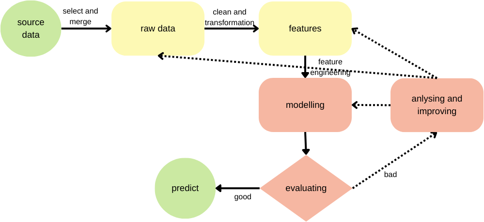

figure 0-1 Project2 Modelling Workflow

## 1.0 Pipline

```r
prepration_pipeline <- function(data,feature_engineering_method=select_more) {
  prepared_data <- data |>
                  data_transformation_pipeline() |>
                  data_cleaning_pipeline() |>
                  feature_engineering_method()

  return(prepared_data)
}

data_transformation_pipeline <- function(data) {
  selected_data <- data |>
                  rename(education.enrollment = Gross.tertiary.education.enrollment....) |>
                  remove_columns() |>
                  merge_columns() |>
                  add_columns()

  return(selected_data)
}

data_cleaning_pipeline <- function(data) {
  cleaned_data <- data |>
                  # step 1: convert invalid values to NA
                  clean_invalid_data() |>
                  # step 2: dealing with missing values
                  drop_rows() |>
                  clean_categorical_data() |>
                  clean_numerical_data()

  return(cleaned_data)
}

#feature_engineering_method 1: select less features(only keep one country information)
select_less <- function(data) {
  selected_data <- data |>
    select(-c(Population,
education.enrollment,
Unemployment.rate,
Urban_population,video.views,uploads))

  return(selected_data)
}

# selcte more features(keep all country information)
select_more <- function(data) {
  selected_data <- data |>
  select(-c(Population,
Unemployment.rate,))
  return(selected_data) }
```

## 1.1 Subset and Merge,add Source Data

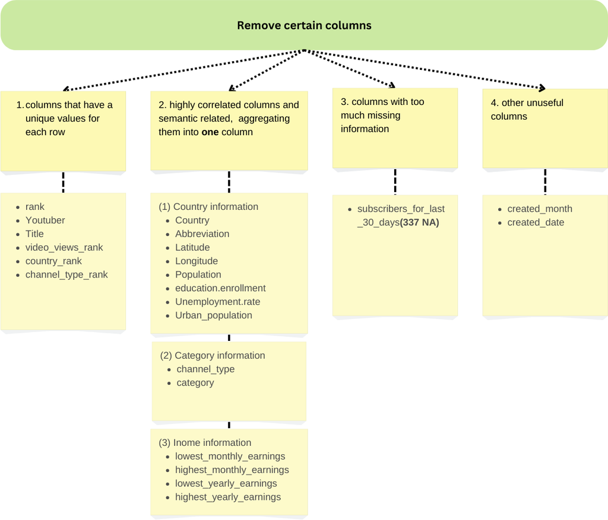

*Figure 1-1. remove certain columns*

1.1 Remove attributes that do not provide useful information for the task

```r
remove_columns <- function(data) {
  remove_vars <- c("rank","Title","Youtuber","channel_type_rank","video_views_rank","country_rank","Abbreviation","Latitude","Longitude","created_month","created_date")

selected_data <- data[, !names(data) %in% remove_vars]

return(selected_data)
}
```

Now, I want to fill in missing values in the channel_type column using values from the category column.

```r
merge_columns <- function(data) {
  merged_data <- data |>
  mutate(
    # Fill missing values in 'channel_type' using values from 'category'
    # create a new variable called channel_category
    channel_type = ifelse(channel_type == "nan", category, channel_type)
  )|>
    # Science & Technology -> Tech
    # Film & Animation -> film
    # Pets & Animals & ->
    # Howto & Style -> Howto
    # Shows ->  Entertainment
    # Gaming -> Games
    # People & Blogs -> People
  mutate(
    channel_type = ifelse(channel_type == "Science & Technology", "Tech", channel_type),
    channel_type = ifelse(channel_type == "Film & Animation", "Film", channel_type),
    channel_type = ifelse(channel_type == "Pets & Animals", "Film", channel_type),
    channel_type = ifelse(channel_type == "Howto & Style", "Howto", channel_type),
    channel_type = ifelse(channel_type == "Shows", "Entertainment", channel_type),
    channel_type = ifelse(channel_type == "Gaming", "Games", channel_type),
    channel_type = ifelse(channel_type == "People & Blogs", "People", channel_type),
  ) |> select(-category) |>
  filter(channel_type != "nan")

  return(merged_data)
}

add_columns <- function(data) {
  added_data <- data |>
  mutate(
    # add new numerical variables
    subscriber_increase_rate = subscribers_for_last_30_days/subscribers,
    views_per_upload = video.views/uploads

  )

  return(added_data)
}
```

## 1.2 Data Cleaning

1.2.2 Invalid Values

```r
clean_invalid_data <- function(data) {
  cleaned_data <-  mutate(data,
                # numerical variable
                # video views 0 -> NA
                video.views = na_if(video.views, 0),
                # created year 1970 -> NA
                created_year = na_if(created_year, 1970),
                # education.enrollment >100 -> NA
                education.enrollment =ifelse(education.enrollment > 100, NA, education.enrollment),
                # uploads == 0 -> NA
                uploads = na_if(uploads, 0)

                )
  #print_nacounts(data)
  return(cleaned_data)
}
```

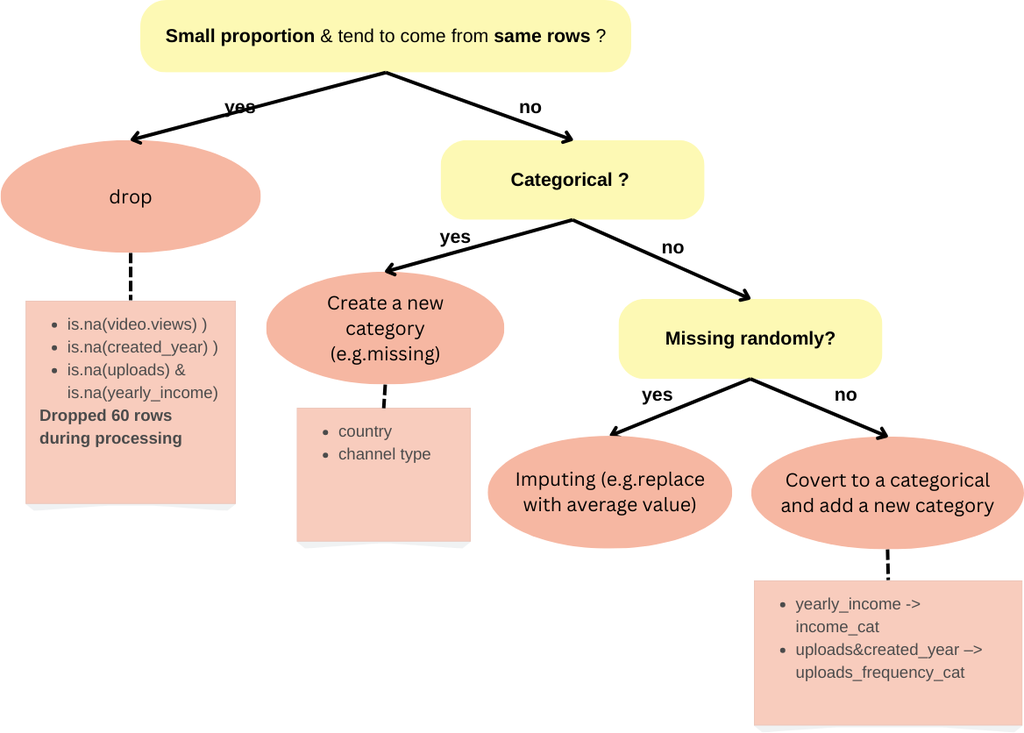

Figure 1-2

1. Drop the rows with missing values

```r
drop_rows <- function(data) {
  cleaned_data <- data |>
  # drop yearly income < 0 (becasue for log scale)
  #filter(yearly_income > 0) |>
  # Remove rows where 'video.views', are NA
  filter(! is.na(video.views)  ) |>
    filter(! is.na(uploads)  ) |>
  filter(! is.na(created_year)  )

return(cleaned_data)

}
```

2. create a new category in categorical variables

```r
clean_categorical_data <- function(data) {
  cleaned_data <- data %>%
  mutate(Country = ifelse(Country == "nan", 'missing', Country)) %>%
  group_by(Country) %>%
  mutate(Country = ifelse(n() < 10, 'other', Country)) %>%
  ungroup() %>%

# Replace 'channel_type' values with 'other' for counts less than 40
  group_by(channel_type) %>%
  mutate(channel_type = ifelse(n() < 10, 'other', channel_type)) %>%
  ungroup() |>
  change_to_factor()

  return(cleaned_data)
}
```

3.numerical missing values

Add `uploads frequency` by caculate two values

In this section, we calculate the `uploads_frequency` variable, which represents the number of uploads for one year.  
This variable is derived from the existing data, specifically the ‘uploads’ and ‘created_year’ variables.

```r
clean_numerical_data <- function(data,cleaning_method) {
  # Calculate time duration
current_year <- 2023

cleaned_data <- data |>
    mutate( age = current_year - created_year,
      uploads_frequency = uploads / age) |>
  within({
  # uploads_freq_cat
  uploads_freq_cat <- NA
  uploads_freq_cat[is.na(uploads_frequency)] <- "missing"
  uploads_freq_cat[uploads_frequency < 10] <- "low"
  uploads_freq_cat[uploads_frequency >= 10 & uploads_frequency <= 1000] <- "middle"
  uploads_freq_cat[uploads_frequency > 1000] <- "high"
  uploads_frequency[is.na(uploads_frequency)] <- 0

  # subscriber_increase_rate
  subscriber_increase_rate[is.na(subscriber_increase_rate)] <- 0

  # Country information
  Population[is.na(Population)] <- 0
  Unemployment.rate[is.na(Unemployment.rate)] <- 0
  education.enrollment[is.na(education.enrollment)] <- 0
  Urban_population[is.na(Urban_population)] <- 0

  # add new categorical variables
  # time_cat
  age_cat <- NA
  age_cat[age <= 3] <- "yong"
  age_cat[age > 3  & age < 13] <- "middle"
  age_cat[age >= 13] <- "old"

}) |> change_to_factor()

cleaned_data <- select(cleaned_data,-created_year,-subscribers_for_last_30_days,-subscribers)
return(cleaned_data)
}
```

# 2. Classification

```r
train_data <- prepration_pipeline(train)
validation_data <- prepration_pipeline(validation)
test_data <- prepration_pipeline(test)

train_prepared <- train_data
test_prepared <- test_data
```

## 2.0 feature selection

Feature selection is a critical step in the machine learning pipeline. It helps in reducing the dimensionality of the dataset, potentially improving the model’s performance, and providing insights into the relationships between the features and the target variable. In this report, we discuss two distinct methods of feature selection employed in the provided code: a Deviance-based method and a Random Forest-based method.

### Deviance-Based Feature Selection

In the Deviance-Based Feature Selection, each feature is individually modeled, and its significance is determined by the difference between null and residual deviance, which essentially captures how much variance the feature explains in the target variable. Features are then ranked by this difference, with those exceeding a score of 50 deemed as influential.

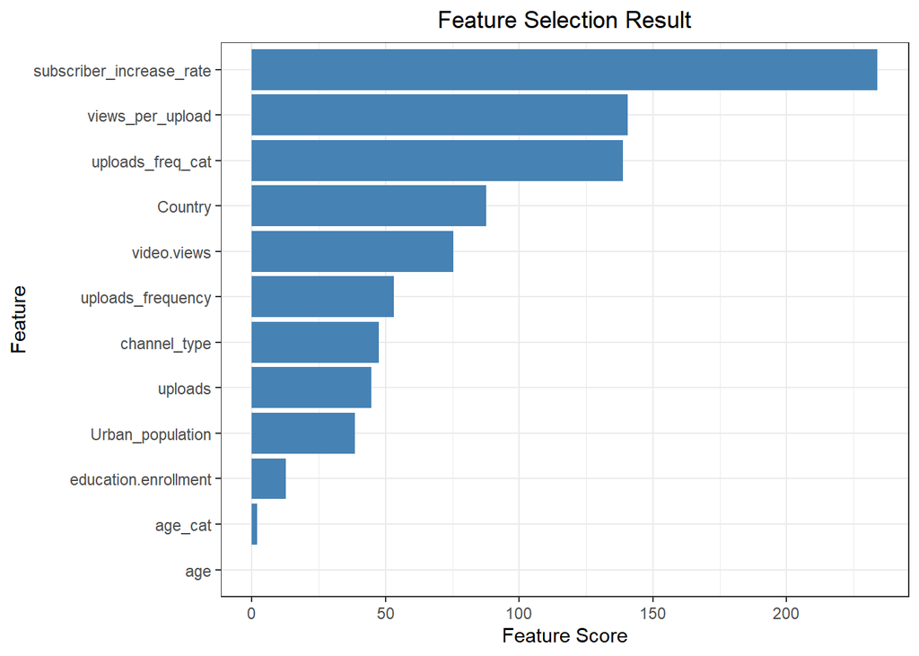

```r
single_variable <- function(data,variable_name,target_variable) {

    suppressWarnings({

      formula <- as.formula(paste(target_variable, "~", variable_name))
      logic_regression <- train(formula, data = data, method = "glm", family = "binomial")

      return(logic_regression)


    })

}




selection_method_1 <- function(data, target_variable) {

  feature_names <- setdiff(colnames(data), target_variable)


  result_df <- data.frame(Feature = feature_names, Feature_Score = numeric(length(feature_names)))


  for (i in seq_along(feature_names)) {
    col_name <- feature_names[i]
    #print(col_name)

    single_variable_model <- single_variable(data, col_name, target_variable)
    summary_result <- summary(single_variable_model)

    null_deviance <- summary_result$null.deviance
    residual_deviance <- summary_result$deviance


      difference <- null_deviance - residual_deviance


      result_df$Feature_Score[i] <- round(difference, 2)

  }

  result_df <- result_df[order(result_df$Feature_Score, decreasing = TRUE), ]

  return(result_df)
}

result <- selection_method_1(train_data, "income_cat")
# plot the result of feature selection to show the feature score
ggplot(result, aes(x = reorder(Feature, Feature_Score), y = Feature_Score)) +
  geom_bar(stat = "identity", fill = "steelblue") +
  coord_flip() +
  labs(x = "Feature", y = "Feature Score", title = "Feature Selection Result") +
  theme_bw() +
  theme(plot.title = element_text(hjust = 0.5))
```

```r
selected_features_1 <- result$Feature[result$Feature_Score > 50]
```

```r
print(selected_features_1)
```

```
## [1] "subscriber_increase_rate" "views_per_upload"         "uploads_freq_cat"         "Country"                  "video.views"
## [6] "uploads_frequency"
```

### Random Forest-Based Feature Selection

Random Forest-Based Feature Selection utilizes the ensemble learning technique of Random Forest to evaluate feature importance. This importance, typically gauged by the Mean Decrease in Gini impurity, provides a holistic view of the collective contribution of features to the predictive power of the model. Features surpassing a MeanDecreaseGini value of 10 are selected as salient.

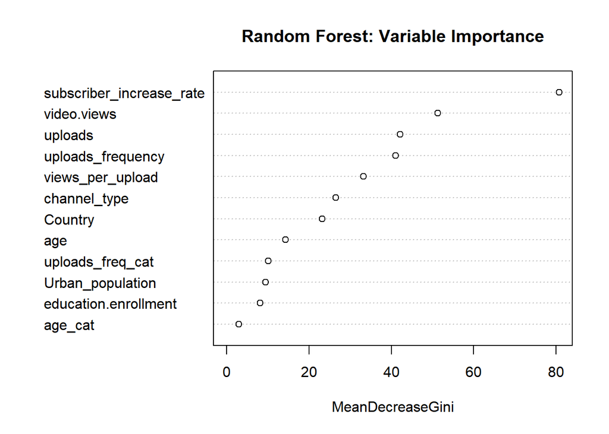

```r
model <- randomForest(income_cat ~ . , data = train_data, ntree = 100)
importance <- importance(model)
#print(importance)

varImpPlot(model, type = 2, main = "Random Forest: Variable Importance")
```

```r
importance_df <- as.data.frame(importance) |>
  filter(MeanDecreaseGini > 10)


selected_features_2 <- rownames(importance_df)
```

```r
print(selected_features_2)
```

```
## [1] "video.views"              "uploads"                  "Country"                  "channel_type"             "subscriber_increase_rate"
## [6] "views_per_upload"         "age"                      "uploads_frequency"        "uploads_freq_cat"
```

Both methods offer unique insights into feature relevance. While the deviance-based approach provides a direct measure of a feature’s relationship with the target, the Random Forest-based approach gives an ensemble perspective, indicating how features jointly contribute to the predictive capability.

## 2.1 Logistic regression

Logistic regression is a classification method that uses a logistic function to model a binary dependent variable. It is a special case of generalized linear regression that predicts the *probability* of the outcome. The logistic regression model is a *linear* model, which means that the logit function is a linear combination of the independent variables.

feature engineering for logistic regression model

References:

Ng, A. Y. (2000). Feature selection, L1 vs. L2 regularization, and rotational invariance. In ICML (Vol. 3, pp. 78). James, G., Witten, D., Hastie, T., & Tibshirani, R. (2013). An Introduction to Statistical Learning. Springer. Hastie, T., Tibshirani, R., & Friedman, J. (2009). The Elements of Statistical Learning: Data Mining, Inference, and Prediction. Springer. Tibshirani, R. (1996). Regression shrinkage and selection via the lasso. Journal of the Royal Statistical Society: Series B (Methodological), 58(1), 267-288.

```r
normalise <- function(data){
  # normalise the numerical data excepet target variable income_cat
  # Extract numeric columns (excluding 'income_cat')
  numeric_columns <- colnames(data[, sapply(data, is.numeric) & colnames(data) != 'income_cat'])

  scaled_data <- data |>
    mutate_at(vars(numeric_columns), ~ (.-mean(.))/sd(.))


  return(scaled_data)
}
```

```r
perform_feature_engineering <- function(data, normalisation = TRUE, selection = 1) {

  if (normalisation == TRUE) {
    data <- normalise(data)
  }

  if (selection == 1) {


    data <- data[, c(selected_features_1, "income_cat")]
  }

  if (selection == 2) {

    data <- data[, c(selected_features_2, "income_cat")]
  }

  return(data)
}
```

Both `model_1` and`model_2` employ logistic regression, yet they adopt different strategies in terms of feature engineering.  
- While `model_1` utilizes the data (with basic cleaning).  
- `model_2` optimizes performance through feature normalization and feature selection.

```r
model_1 <- suppressWarnings({glm(income_cat ~ .,
               data = perform_feature_engineering(train_data, normalisation = FALSE, selection = 0),
               family = "binomial") })
```

```r
model_2 <- suppressWarnings({
          glm(income_cat ~ .,
               data = perform_feature_engineering(train_data, normalisation = TRUE, selection = 1),
               family = "binomial")
          })

print(summary(model_2))
```

```
##
## Call:
## glm(formula = income_cat ~ ., family = "binomial", data = perform_feature_engineering(train_data,
##     normalisation = TRUE, selection = 1))
##
## Coefficients:
##                          Estimate Std. Error z value Pr(>|z|)
## (Intercept)                3.8225     1.5415   2.480 0.013149 *
## subscriber_increase_rate   4.1919     0.5667   7.398 1.39e-13 ***
## views_per_upload          -9.0798     2.5594  -3.548 0.000389 ***
## uploads_freq_catlow       -0.7855     0.8717  -0.901 0.367550
## uploads_freq_catmiddle    -0.5823     0.7617  -0.765 0.444566
## CountryBrazil             -1.3819     1.4750  -0.937 0.348805
## CountryCanada             -1.8822     1.6317  -1.154 0.248696
## CountryColombia           11.6001   621.1878   0.019 0.985101
## CountryIndia              -1.5576     1.4655  -1.063 0.287833
## CountryIndonesia          -1.5721     1.5387  -1.022 0.306910
## CountryMexico             -1.3988     1.5072  -0.928 0.353376
## Countrymissing            -2.7900     1.4788  -1.887 0.059207 .
## Countryother              -1.9944     1.4613  -1.365 0.172323
## CountryPhilippines        -2.8639     1.7415  -1.644 0.100077
## CountryRussia             -1.0216     1.7108  -0.597 0.550422
## CountrySouth Korea        -2.8956     1.6371  -1.769 0.076938 .
## CountrySpain              -2.5420     1.5271  -1.665 0.096004 .
## CountryThailand           -1.7235     1.7137  -1.006 0.314553
## CountryUnited Kingdom     -0.9886     1.4900  -0.663 0.507022
## CountryUnited States      -1.7748     1.4371  -1.235 0.216842
## video.views                2.6842     0.3447   7.786 6.91e-15 ***
## uploads_frequency          0.2803     0.3966   0.707 0.479806
## ---
## Signif. codes:  0 '***' 0.001 '**' 0.01 '*' 0.05 '.' 0.1 ' ' 1
##
## (Dispersion parameter for binomial family taken to be 1)
##
##     Null deviance: 1011.11  on 848  degrees of freedom
## Residual deviance:  554.68  on 827  degrees of freedom
## AIC: 598.68
##
## Number of Fisher Scoring iterations: 15
```

Logistic Regression Summary:

Surprisingly, channels with more views per individual upload appear to be less likely to fall into higher income brackets. This may suggest that sporadic viral content doesn’t necessarily translate to consistent income, as opposed to channels that maintain steady viewership across multiple videos.

The country of content origin also influences a channel’s income, though its impact is varied.

In summary, in this part, the logistic regression model was constructed to predict the income_cat target variable using various YouTube metrics and country factors. The perform_feature_engineering function was applied to the dataset prior to modeling to ensure optimal feature selection.

## 2.2 Decision Tree

Decision tree is a classification method that uses a *tree-like* graph to model the decisions and their possible consequences. It is a supervised learning method that can be used for both classification and regression problems. Not like logistic regression, decision tree is a *non-linear* model, which means that the decision boundary is not a linear combination of the independent variables. Decision tree is a *white box* model, which means that the decision process can be explained by the tree structure.

feature engineering for decision tree model

1. do not need to normalize numerical variables

2. do not need to add interaction terms

3. do not need one hot encoding for categorical variables

4. using Gini index to select features
5. overfitting: pruning

Both models employ decision trees  
- `model_3` provides a straightforward approach without feature selection.  
- `model_4` advances this with feature selection, cross-validation, and hyperparameter tuning for enhanced accuracy and generalization.

```r
# decision tree without feature selection
model_3 <- rpart(income_cat ~ .,
                 data = perform_feature_engineering(train_data, normalisation = FALSE, selection = 0),
                 method = "class")
```

```r
print(model_3)
```

```
## n= 849
##
## node), split, n, loss, yval, (yprob)
##       * denotes terminal node
##
##  1) root 849 240 1 (0.28268551 0.71731449)
##    2) subscriber_increase_rate< 0.0008189203 316 115 0 (0.63607595 0.36392405)
##      4) uploads< 95 90   4 0 (0.95555556 0.04444444) *
##      5) uploads>=95 226 111 0 (0.50884956 0.49115044)
##       10) video.views< 6.159627e+09 123  30 0 (0.75609756 0.24390244) *
##       11) video.views>=6.159627e+09 103  22 1 (0.21359223 0.78640777)
##         22) channel_type=Comedy,Film,News,People 12   4 0 (0.66666667 0.33333333) *
##         23) channel_type=Education,Entertainment,Games,Howto,Music 91  14 1 (0.15384615 0.84615385) *
##    3) subscriber_increase_rate>=0.0008189203 533  39 1 (0.07317073 0.92682927)
##      6) video.views< 1.518692e+09 16   6 0 (0.62500000 0.37500000) *
##      7) video.views>=1.518692e+09 517  29 1 (0.05609284 0.94390716) *
```

```r
#decision tree with feature selection and

ctrl <- trainControl(method = "cv", number = 5)


param_grid <- expand.grid(cp = seq(0.01, 0.15, by = 0.01))

model_4 <- train(
  income_cat ~ .,
  data = perform_feature_engineering(train_data, normalisation = FALSE, selection = 2),
  method = "rpart",
  trControl = ctrl,
  tuneGrid = param_grid
)
```

```r
print(model_4)
```

```
## CART
##
## 849 samples
##   9 predictor
##   2 classes: '0', '1'
##
## No pre-processing
## Resampling: Cross-Validated (5 fold)
## Summary of sample sizes: 680, 679, 679, 679, 679
## Resampling results across tuning parameters:
##
##   cp    Accuracy   Kappa
##   0.01  0.8668848  0.6612716
##   0.02  0.8727671  0.6719321
##   0.03  0.8739436  0.6746365
##   0.04  0.8739436  0.6733063
##   0.05  0.8739436  0.6733063
##   0.06  0.8739436  0.6733063
##   0.07  0.8739436  0.6733063
##   0.08  0.8739436  0.6733063
##   0.09  0.8739436  0.6733063
##   0.10  0.8739436  0.6733063
##   0.11  0.8739436  0.6733063
##   0.12  0.8515141  0.6417248
##   0.13  0.8162200  0.5866893
##   0.14  0.8162200  0.5866893
##   0.15  0.8162200  0.5866893
##
## Accuracy was used to select the optimal model using the largest value.
## The final value used for the model was cp = 0.11.
```

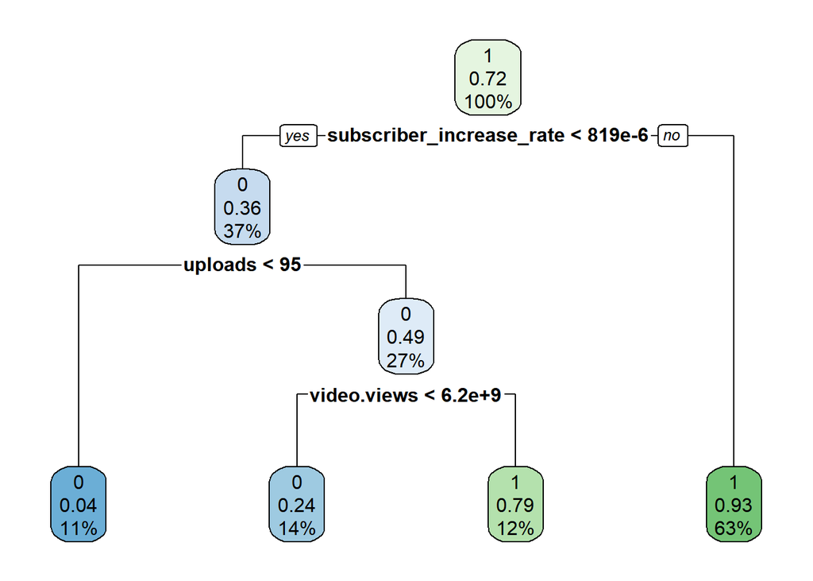

```r
library(rpart.plot)


best_model <- rpart(income_cat ~ .,
                    data = perform_feature_engineering(train_data, normalisation = FALSE, selection = 2),
                    method = "class",
                    control = rpart.control(cp = model_4$bestTune$cp))


rpart.plot(best_model)
```

```r
print(best_model)
```

```
## n= 849
##
## node), split, n, loss, yval, (yprob)
##       * denotes terminal node
##
##  1) root 849 240 1 (0.28268551 0.71731449)
##    2) subscriber_increase_rate< 0.0008189203 316 115 0 (0.63607595 0.36392405)
##      4) uploads< 95 90   4 0 (0.95555556 0.04444444) *
##      5) uploads>=95 226 111 0 (0.50884956 0.49115044)
##       10) video.views< 6.159627e+09 123  30 0 (0.75609756 0.24390244) *
##       11) video.views>=6.159627e+09 103  22 1 (0.21359223 0.78640777) *
##    3) subscriber_increase_rate>=0.0008189203 533  39 1 (0.07317073 0.92682927) *
```

Decision Tree Classification Summary:

- The decision tree primarily differentiates channels based on their `subscriber_increase_rate`. Those with a higher subscriber rate are predominantly classified as high income (class 1). Conversely: Channels with a lower subscriber rate and fewer uploads (below 95) are almost always categorized as low income (class 0).
- Among channels with a lower subscriber rate but with more uploads (95 and above), the classification is further influenced by `video.views`. Those with fewer video views are likely to be low income, while channels with more video views lean towards high income.

To summarize, the `subscriber_increase_rate` is the most pivotal determinant. For channels with a lower subscriber rate, the number of uploads and video views further define the income classification, with high views indicating a greater likelihood of high income.

Here are the condensed insights based on the decision tree:

- *Subscriber Growth* as a Key Predictor: The recent subscriber growth rate is a primary determinant of a channel’s income class. Channels experiencing a rapid increase in subscribers in the past 30 days are highly likely to belong to the high-income category, highlighting the value of audience acquisition and retention in short bursts.
- *Balancing Upload Frequency and Engagement*: For channels with slower subscriber growth, having a higher number of lifetime uploads and a significant number of video views can still position them in the high-income bracket. This underscores the dual importance of content consistency and engagement in driving channel revenue, even if recent subscriber growth is not explosive.
- *Potential of High Viewership*: Channels with extensive video views, even in the face of moderate subscriber growth, tend to secure higher income. This insight suggests that a channel’s ability to draw views and maintain engagement can serve as a powerful lever for monetization, beyond just subscriber numbers.

## 2.4 SVM & LIME

choose features for svm model

```r
ctrl_svm <- rfeControl(functions = rfFuncs, method = "cv")

result_svm <- rfe(x = train_data[, !(colnames(train_data) %in% c("income_cat"))],
                  y = train_data$income_cat,
                  sizes = c(1, 2, 3),
                  rfeControl = ctrl_svm)


selected_features_svm <- result_svm$optVariables
selected_features_svm
```

```
## [1] "subscriber_increase_rate" "video.views"              "uploads"
```

Use these three selected variables for SVM

```r
library(e1071)

svm_model <- svm(income_cat ~ ., data = train_data[, c("income_cat", selected_features_svm)], kernel = "linear", probability = TRUE)
summary(svm_model)
```

```
##
## Call:
## svm(formula = income_cat ~ ., data = train_data[, c("income_cat", selected_features_svm)], kernel = "linear", probability = TRUE)
##
##
## Parameters:
##    SVM-Type:  C-classification
##  SVM-Kernel:  linear
##        cost:  1
##
## Number of Support Vectors:  415
##
##  ( 207 208 )
##
##
## Number of Classes:  2
##
## Levels:
##  0 1
```

This SVM model has 415 support vectors, which are data points considered critical for defining the decision boundary. Support vectors play a central role in determining the classification task.

Then we Create a LIME explainer

```r
library(lime)

# Create an explainer object
explainer_svm <- explain(model = svm_model,
                         data = train_data[, selected_features_svm],
                         y = train_data$income_cat,
                         type = "classification"
                         , n_permutations = 100)
```

[output not shown]

```
##   -> residuals         :  numerical, min =  NA , mean =  NA , max =  NA
##   A new explainer has been created!
```

```r
explainer_svm
```

```
## Model label:  svm
## Model class:  svm.formula,svm
## Data head  :
##   subscriber_increase_rate video.views uploads
## 1              0.000000000  2851024430      17
## 2              0.005434783 11544297793    3159
```

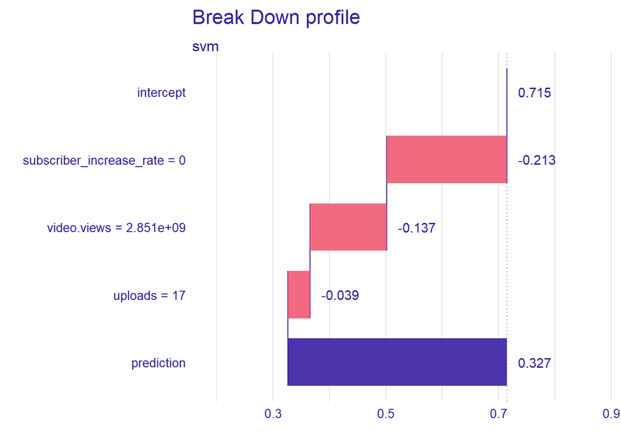

```r
# Create a data frame with a single observation
new_data_observation <- data.frame(
  subscriber_increase_rate = train_data[1, "subscriber_increase_rate"],
  video.views = train_data[1, "video.views"],
  uploads = train_data[1, "uploads"]
)

# Use predict_parts with the explainer to generate feature importances:
explanations_svm <- predict_parts(explainer_svm, new_observation = new_data_observation, n_labels = 2)

plot(explanations_svm)
```

## 2.5 Model Comparison on Validation Data

Using the validation data, predictions were generated for four models: two logistic regressions (with and without feature engineering) and two decision trees (with varying levels of optimization). These predictions were then assessed using *Receiver Operating Characteristic (ROC)* curves, with each model represented by a distinct color. The plot combined the ROC curves of all models, providing a visual comparison of their performance, and displayed the *Area Under the Curve (AUC)* values, a metric that quantifies each model’s ability to distinguish between classes. The overall comparison aids in discerning the efficacy of each model in handling the given data.

```r
predictions1 <- predict(model_1,
                        newdata = perform_feature_engineering(validation_data, normalisation = FALSE, selection = 0),
                        type = "response")




predictions2 <- predict(model_2,
                        newdata = perform_feature_engineering(validation_data, normalisation = TRUE, selection = 1),
                        type = "response")

predictions3 <- predict(model_3,
                        newdata = perform_feature_engineering(validation_data, normalisation = FALSE, selection = 0),
                        type = "prob")



predictions4 <- predict(model_4,
                        newdata = perform_feature_engineering(validation_data, normalisation = FALSE, selection = 2),
                        type = "prob")
```

```r
roc_obj1 <- suppressWarnings({roc(validation_data$income_cat, predictions1)})
roc_obj2 <- suppressWarnings({roc(validation_data$income_cat, predictions2)})
roc_obj3 <- suppressWarnings({roc(validation_data$income_cat, predictions3[,2])})
roc_obj4 <- suppressWarnings({roc(validation_data$income_cat, predictions4[,2])})
```

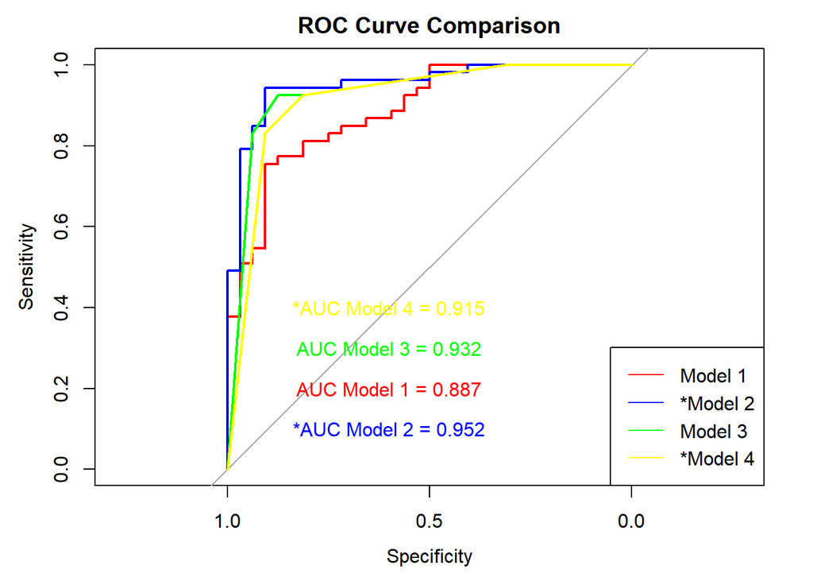

```r
plot(roc_obj1, col = "red", main = "ROC Curve Comparison")
lines(roc_obj2, col = "blue")
lines(roc_obj3, col = "green")
lines(roc_obj4, col = "yellow")

legend("bottomright", legend = c("Model 1", "*Model 2","Model 3","*Model 4"), col = c("red", "blue","green","yellow"), lty = 1)



text(0.6, 0.2, labels = paste("AUC Model 1 =", round(auc(roc_obj1), 3)), col = "red")
text(0.6, 0.1, labels = paste("*AUC Model 2 =", round(auc(roc_obj2), 3)), col = "blue")
text(0.6, 0.3, labels = paste("AUC Model 3 =", round(auc(roc_obj3), 3)), col = "green")
text(0.6, 0.4, labels = paste("*AUC Model 4 =", round(auc(roc_obj4), 3)), col = "yellow")
```

Based on the ROC Curve Comparison:

- *Logistic Regression*: Model 2, which underwent feature engineering and feature selection, shows a *significant improvement* in predictive performance compared to Model 1. This indicates that the modifications in data preprocessing and feature handling notably enhanced the performance of the logistic regression model.
- *Decision Trees*: Model 4, in contrast to Model 2, does *not* exhibit a notably superior performance compared to Model 3.

The minimal difference between these models suggests that *decision trees* inherently have a strong predictive capability, and the added feature engineering and selection did not yield a significant advantage.

In summary, while feature engineering and selection considerably boosted the performance of the logistic regression model, the decision tree’s sophisticated nature means it benefits less from such enhancements. This underscores the importance of model-specific optimizations when improving prediction accuracy.

## 2.6 Performance Evaluation on Test Data

The performance of two models, a logistic regression (model_2) and a decision tree (model_4), was evaluated on the test dataset.

### ROC Curve Comparison

Receiver Operating Characteristic (ROC) curves were plotted to assess and compare the models’ performances. The logistic regression model’s ROC curve was colored in red, while the decision tree model was represented in blue. The visualized curves were accompanied by their respective Area Under the Curve (AUC) values, offering a numerical insight into each model’s ability to discriminate between the target classes.

```r
# test data
# logic regression
pred_test_1 <- predict(model_2,
                        newdata = perform_feature_engineering(test_data, normalisation = TRUE, selection = 0),
                        type = "response")

# decision tree
pred_test_2 <- predict(model_4,
                        newdata = perform_feature_engineering(test_data, normalisation = FALSE, selection = 2),
                        type = "prob")
```

```r
# ROC
roc_obj_test_1 <- suppressWarnings({roc(test_data$income_cat, pred_test_1)})
roc_obj_test_2 <- suppressWarnings({roc(test_data$income_cat, pred_test_2[,2])})
```

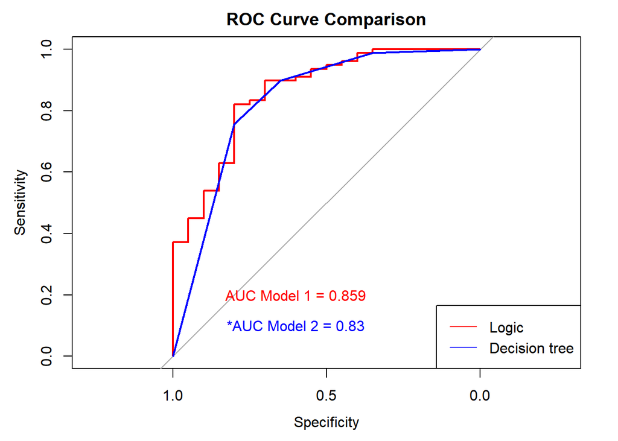

```r
plot(roc_obj_test_1, col = "red", main = "ROC Curve Comparison")
lines(roc_obj_test_2, col = "blue")
legend("bottomright", legend = c("Logic", "Decision tree"), col = c("red", "blue"), lty = 1)
text(0.6, 0.2, labels = paste("AUC Model 1 =", round(auc(roc_obj_test_1), 3)), col = "red")
text(0.6, 0.1, labels = paste("*AUC Model 2 =", round(auc(roc_obj_test_2), 3)), col = "blue")
```

- Overfitting: As you pointed out, the *decision tree* model performed **better** on the *validation set* compared to the *test set*, suggesting the possibility of *overfitting*. Decision trees are known to be prone to overfitting, especially when they are deep and capture noise in the data. This emphasizes the importance of pruning or setting depth constraints when working with decision trees.
- Consistency across Datasets: Despite potential overfitting, the decision tree model *still performed comparably* to the logic model on the test set. This suggests that, while the decision tree might capture more intricate patterns (which can sometimes be noise), it still holds valuable generalized predictive power.
- Reflection: It would be beneficial to further tune the decision tree model to *minimize overfitting*, potentially using techniques like *cross-validation*. This could help ensure consistent performance across different data sets.

### Confusion Matrix Comparison

In evaluating the models on the test data, *a threshold of 0.5* was applied to the probabilistic predictions to derive binary class labels for both the logistic regression and decision tree models.  
Subsequently, confusion matrices were constructed for each model, offering a comprehensive breakdown of their respective classification performances. These matrices not only provide metrics like *accuracy*, *precision*, and *recall* but also pinpoint where each model *excels or errs* in its predictions.

```r
pred_1 <- as.factor(ifelse(pred_test_1 > 0.5, 1, 0))


#print(pred_1)
confusionMatrix(pred_1, test_data$income_cat)
```

```
## Confusion Matrix and Statistics
##
##           Reference
## Prediction  0  1
##          0 16 18
##          1  4 60
##
##                Accuracy : 0.7755
##                  95% CI : (0.6801, 0.8536)
##     No Information Rate : 0.7959
##     P-Value [Acc > NIR] : 0.739380
##
##                   Kappa : 0.4517
##
##  Mcnemar's Test P-Value : 0.005578
##
##             Sensitivity : 0.8000
##             Specificity : 0.7692
##          Pos Pred Value : 0.4706
##          Neg Pred Value : 0.9375
##              Prevalence : 0.2041
##          Detection Rate : 0.1633
##    Detection Prevalence : 0.3469
##       Balanced Accuracy : 0.7846
##
##        'Positive' Class : 0
##
```

```r
pred_2 <- as.factor(ifelse(pred_test_2[,2] > 0.5, 1, 0))
confusionMatrix(pred_2, test_data$income_cat)
```

```
## Confusion Matrix and Statistics
##
##           Reference
## Prediction  0  1
##          0 13  8
##          1  7 70
##
##                Accuracy : 0.8469
##                  95% CI : (0.7601, 0.9117)
##     No Information Rate : 0.7959
##     P-Value [Acc > NIR] : 0.1279
##
##                   Kappa : 0.5374
##
##  Mcnemar's Test P-Value : 1.0000
##
##             Sensitivity : 0.6500
##             Specificity : 0.8974
##          Pos Pred Value : 0.6190
##          Neg Pred Value : 0.9091
##              Prevalence : 0.2041
##          Detection Rate : 0.1327
##    Detection Prevalence : 0.2143
##       Balanced Accuracy : 0.7737
##
##        'Positive' Class : 0
##
```

# 3. Clustering

## 3.1 Scaling

1. Scaling variables so that the dataset has a mean of 0 and a standard deviation of 1
2. Use the PCA() function to perform PCA to reduce the dimensionality of data and decorrelate variables

```r
library(FactoMineR)

df_cluster <-data_cleaning_pipeline(data_transformation_pipeline(df))

get_scaled_df <- function(df, vars_not_to_use) {
  vars_to_scale <- setdiff(names(df), vars_not_to_use)
  scaled_df <- scale(df[, vars_to_scale])
  scaled_df <- as.matrix(scaled_df[complete.cases(scaled_df), ])
  return(scaled_df)
}

get_scaled_center_and_scale <- function(df, vars_not_to_use) {
  vars_to_scale <- setdiff(names(df), vars_not_to_use)
  scaled_df <- scale(df[, vars_to_scale])
  center <- attr(scaled_df, "scaled:center")
  scale <- attr(scaled_df, "scaled:scale")
  return(list(center = center, scale = scale))
}

# skip categorical variables
vars_not_to_use <- c("Country", "channel_type","age_cat","uploads_freq_cat","lowest_yearly_earnings","highest_yearly_earnings")
scaled_cluster <- get_scaled_df(df_cluster, vars_not_to_use)

pca_result <- PCA(scaled_cluster, scale.unit = TRUE, graph = FALSE)
pca_result$call$col.w
```

```
##  [1] 1 1 1 1 1 1 1 1 1 1 1 1 1
```

All the weights are set to 1, which means that all the variables have equal weights in the PCA. Sp we will use these variables for clustering.

## 3.2 Hierarchical Clustering

Hierarchical Clustering is more flexible and can be used for a wider range of data types. It doesn’t require to specify the number of clusters in advance compared to k-means.

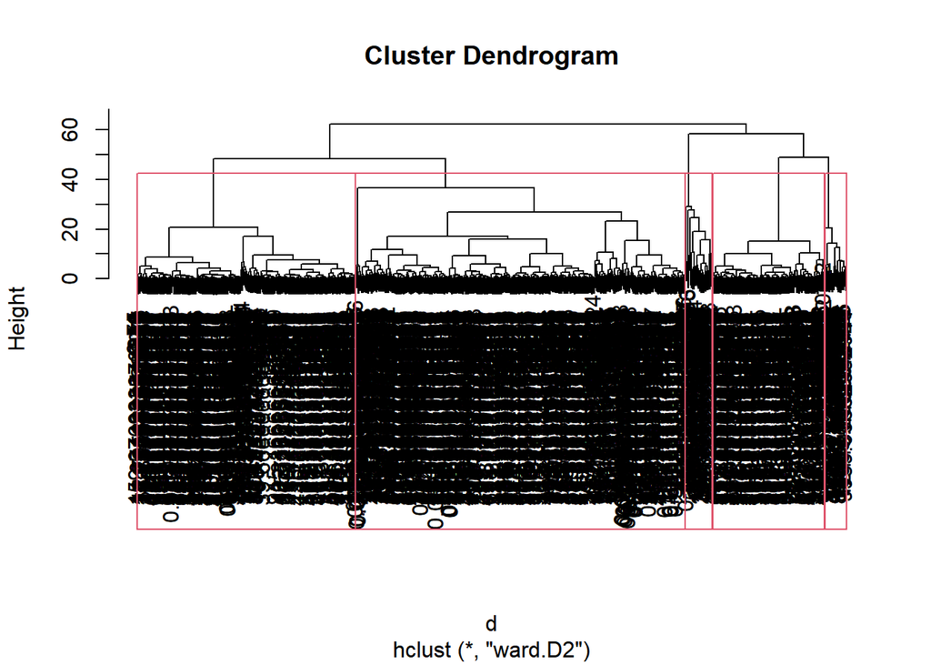

```r
d <- dist(scaled_cluster, method = "euclidean")
pfit <- hclust(d, method="ward.D2")
df_cluster <- na.omit(df_cluster)
plot(pfit, labels=df_cluster$uploads_frequency, main="Cluster Dendrogram")
rect.hclust(pfit, k=5)
```

### Visualsation

```r
princ <- prcomp(scaled_cluster)  # Principal components of scaled_cluster
nComp <- 2  # First two principal components
project2D <- as.data.frame(predict(princ, newdata = scaled_cluster)[, 1:nComp])
hclust.project2D <- cbind(project2D, cluster = as.factor(cutree(pfit, k=5)), channel = df_cluster$channel_type)

head(hclust.project2D)
```

```
##          PC1          PC2 cluster       channel
## 1 -14.402938  1.595164125       1         Music
## 2  -6.047130  2.954560251       1 Entertainment
## 3 -10.994264  3.874726812       1     Education
## 4 -11.605739 -1.357705553       1 Entertainment
## 5  -3.990397  1.907194564       2 Entertainment
## 6   0.544165  0.002765415       3 Entertainment
```

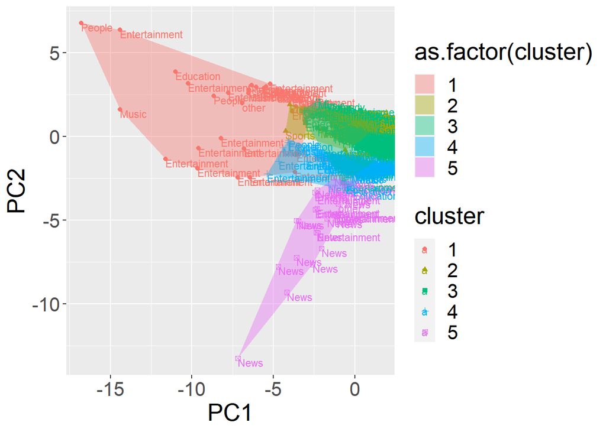

```r
library('grDevices')
find_convex_hull <- function(proj2Ddf) {
do.call(rbind,
lapply(unique(cutree(pfit, k=5)),
FUN = function(c) {
f <- subset(proj2Ddf, cluster==c);
f[chull(f),]
}))}

hclust.hull <- find_convex_hull(hclust.project2D)

library(ggplot2)
ggplot(hclust.project2D, aes(x=PC1, y=PC2)) +
geom_point(aes(shape=cluster, color=cluster)) +
geom_text(aes(label=channel, color=cluster), hjust=0, vjust=1, size=3) +
geom_polygon(data=hclust.hull, aes(group=cluster, fill=as.factor(cluster)),
alpha=0.4, linetype=0) + theme(text=element_text(size=20))
```

We could observe the channel types in each cluster.

Because we have 900+ obs in the dataset,it’s hard to check the clusters. We need to use samples

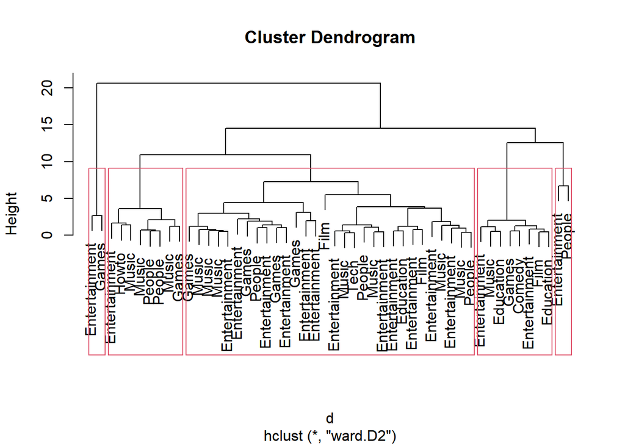

```
## WSS for Cluster 1 : 65.4246166267765
## WSS for Cluster 2 : 145.734674416326
## WSS for Cluster 3 : 151.287899983541
## WSS for Cluster 4 : 496.189324313617
## WSS for Cluster 5 : 91.6056096187777
## Total WSS (Within-Cluster Sum of Squares): 950.2421
```

```r
library(stats)  # Required for the dist function

# we could use different sample_size and k-values to cluster
performHierarchicalClustering <- function(scaled_cluster, df_cluster, sample_size, num_of_cluster) {
  set.seed(123)  # Set a seed for reproducibility
  # Randomly sample a subset of data
  sample_indices <- sample(1:nrow(scaled_cluster), sample_size)
  subset_scaled_cluster <- scaled_cluster[sample_indices, ]
  subset_df_cluster <- df_cluster[sample_indices, ]

  d <- dist(subset_scaled_cluster, method = "euclidean")
  pfit <- hclust(d, method = "ward.D2")
  plot(pfit, labels = subset_df_cluster$channel_type, main = "Cluster Dendrogram")

  num_clusters <- num_of_cluster
  rect.hclust(pfit, k = num_clusters)

  # Calculate the Within-Cluster Sum of Squares (WSS)
  clusters <- cutree(pfit, k = num_clusters)
  # Initialize an empty vector to store WSS values for each cluster
  wss <- numeric(num_clusters)


  # Calculate WSS for each cluster
  for (i in 1:num_clusters) {
    cluster_points <- subset_scaled_cluster[cutree(pfit, k=5) == i, ]
    cluster_center <- colMeans(cluster_points)
    cluster_wss <- sum(rowSums((cluster_points - cluster_center)^2))
    wss[i] <- cluster_wss
    cat(paste("WSS for Cluster", i, ":", cluster_wss, "\n"))
  }
  # Calculate and print the total WSS
  cat("Total WSS (Within-Cluster Sum of Squares):", sum(wss), "\n")


  return(list(pfit, subset_df_cluster))
}

hierarchical_result <- performHierarchicalClustering(scaled_cluster, df_cluster, 50,5)
```

```r
s_groups <- cutree(hierarchical_result[[1]], k=5)

print_clusters <- function(df, groups, cols_to_print) {
Ngroups <- max(groups)
for (i in 1:Ngroups) {
print(paste("cluster", i))
print(df[groups == i, cols_to_print])
}
}
print_clusters(hierarchical_result[[2]], s_groups, c("channel_type","age_cat","uploads_freq_cat","highest_monthly_earnings"))
```

```
## [1] "cluster 1"
## # A tibble: 8 × 4
##   channel_type  age_cat uploads_freq_cat highest_monthly_earnings
##   <fct>         <fct>   <fct>                               <dbl>
## 1 People        middle  low                                  0.03
## 2 Howto         middle  middle                           93100
## 3 People        middle  middle                           87300
## 4 Entertainment old     low                                  0.08
## 5 Music         middle  middle                          394900
## 6 Music         old     low                                  2
## 7 Music         middle  middle                              42
## 8 Games         middle  middle                          394600
## [1] "cluster 2"
## # A tibble: 30 × 4
##    channel_type  age_cat uploads_freq_cat highest_monthly_earnings
##    <fct>         <fct>   <fct>                               <dbl>
##  1 People        middle  middle                                  0
##  2 Music         old     middle                             361800
##  3 Entertainment middle  middle                              97500
##  4 Games         middle  middle                             282800
##  5 Music         middle  middle                             222600
##  6 Entertainment middle  middle                             735500
##  7 Music         old     middle                              21800
##  8 Entertainment old     middle                              92800
##  9 Entertainment middle  middle                              10800
## 10 Education     middle  middle                             308200
## # ℹ 20 more rows
## [1] "cluster 3"
## # A tibble: 8 × 4
##   channel_type  age_cat uploads_freq_cat highest_monthly_earnings
##   <fct>         <fct>   <fct>                               <dbl>
## 1 Film          middle  middle                             398700
## 2 Games         middle  middle                              23700
## 3 Entertainment middle  high                               616200
## 4 Education     middle  middle                             314600
## 5 Entertainment middle  middle                             556500
## 6 Comedy        middle  middle                             111900
## 7 Music         middle  middle                             450600
## 8 Education     middle  middle                             439300
## [1] "cluster 4"
## # A tibble: 2 × 4
##   channel_type  age_cat uploads_freq_cat highest_monthly_earnings
##   <fct>         <fct>   <fct>                               <dbl>
## 1 Entertainment yong    low                                  0
## 2 Games         yong    low                                  0.01
## [1] "cluster 5"
## # A tibble: 2 × 4
##   channel_type  age_cat uploads_freq_cat highest_monthly_earnings
##   <fct>         <fct>   <fct>                               <dbl>
## 1 Entertainment old     high                              4800000
## 2 People        yong    high                              4700000
```

Features in cluster 4 are very distinctive. New established, low upload frequency and very low earnings channels.

And according to the polygon plot, cluster1 and 5 should have significantly different characteristics. They have opposite upload frequency and earnings in cluster 5 are the highest among all clusters.

### Evaluation

**Clustering is unsupervised, so there’s no ground truth to evaluate against.**

In terms of Visual inspection and domain knowledge, our clustering model does divide the otherwise complex dataset into clusters with their own characteristics based on the input variables we choose(upload freq, channel age, and earning).

We still need to evaluate it using within-cluster sum of squares to provide insight into the quality of the clusters

WSS for Cluster 1 : 65.4246166267765 WSS for Cluster 2 : 145.734674416326 WSS for Cluster 3 : 151.287899983541 WSS for Cluster 4 : 496.189324313617 WSS for Cluster 5 : 91.6056096187777 Total WSS (Within-Cluster Sum of Squares): 950.2421

Interpretation:

- Smaller cluster-specific WSS values (e.g., Cluster 1,5) indicate that data points within the cluster are closer to each other and the centroid, suggesting a more compact and well-defined cluster.
- Larger cluster-specific WSS values (e.g., Cluster 4) indicate that data points within the cluster are more spread out, which can suggest a less homogeneous or less well-defined cluster. (Seems There is some conflict with perception because, as explained before cluster 4 clearly has been well grouped with distinctive features. Possible reasons maybe 1. sample-size is not enough. 2. poor performance of the clustering model)
- The total WSS gives us an overall measure of how well the data points are grouped into clusters. Smaller total WSS values suggest better clustering since the data points are more tightly grouped into their respective clusters.

## 3.3 K-means

### Choosing an Appropriate K Value:

When k=1 the WCSS has the highest value but with increasing k value WCSS value starts to decrease. We choose that value of k (optimal k) from where the graph starts to look like a straight line.

[figure not shown]

```r
k <- 6
kmeans_result <- kmeans(scaled_cluster, centers = k)

# Access the cluster assignments for each data point
cluster_assignments <- kmeans_result$cluster

df_cluster$cluster <- cluster_assignments

# We can also access other information about the clustering result, such as cluster centroids:
centroids <- kmeans_result$centers
print(centroids)
```

```
##   video.views     uploads video_views_for_the_last_30_days lowest_monthly_earnings highest_monthly_earnings education.enrollment Population
## 1 -0.09210671 -0.20812245                      -0.16813559             -0.18852799              -0.18857414           0.83574833 -0.2401227
## 2 -0.14397251 -0.08660649                      -0.07983117             -0.04965342              -0.05012387          -0.89268646  2.0778232
## 3  1.99803296  0.44076690                       2.48251306              3.61114734               3.61129368           0.05126059  0.1629451
## 4 -0.10573781 -0.18666803                      -0.19660183             -0.23282887              -0.23264763          -0.51281999 -0.6889660
## 5 -0.68184016 -0.25719055                      14.84507664             -0.52960583              -0.52979093           0.43507430 -0.2570213
## 6  0.28006670  4.95297770                       0.08061161              0.18040442               0.18123388          -0.51248202  0.5298853
##   Unemployment.rate Urban_population subscriber_increase_rate views_per_upload        age uploads_frequency
## 1        1.04751808        0.1719500              -0.18396957       -0.1524720  0.2037114       -0.19738795
## 2       -0.55389408        1.6714178               0.13260746       -0.1555888 -0.3422324       -0.05677219
## 3        0.02470077        0.1663068               2.30839864       -0.1721367 -0.4731267        0.43530856
## 4       -0.91082341       -0.9649368              -0.13494633        0.2071753 -0.0679875       -0.17390325
## 5        0.93189000        0.1486915              -0.27114744       -0.1795851  0.2871739       -0.24996005
## 6       -0.57483616        0.2780233               0.01823417       -0.1800004  0.6380818        4.50079059
```

Variable Centroids: The remaining columns represent the centroids (mean values) of the variables for each cluster. These values indicate the typical or average value of each variable within each cluster.

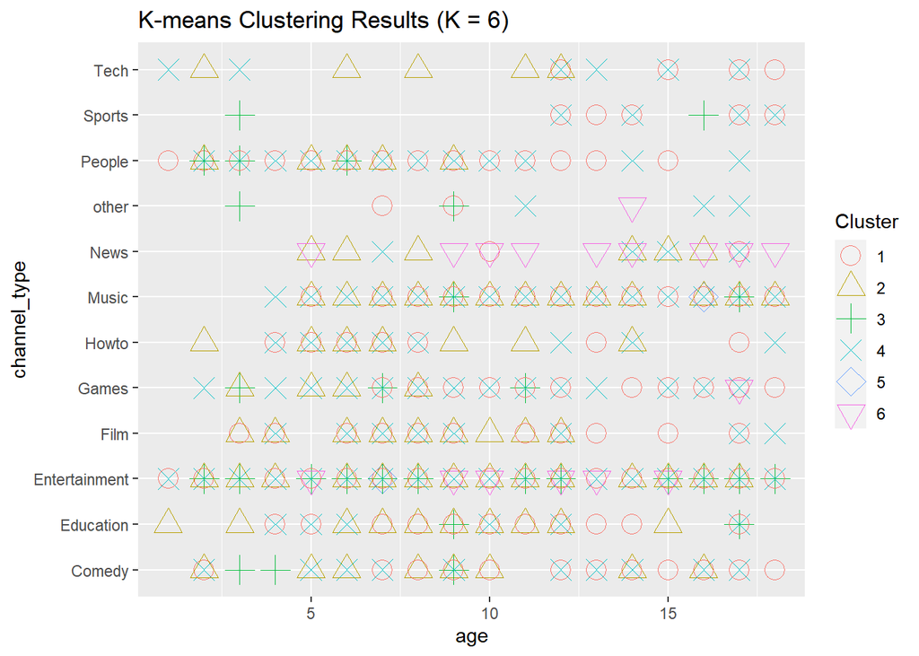

```r
# Create a scatterplot with different pch values for each cluster
kmeans_data <- data.frame(age = df_cluster$age,
                   channel_type = df_cluster$channel_type,
                   Cluster = factor(df_cluster$cluster))
library(ggplot2)
ggplot(kmeans_data, aes(x = age, y = channel_type, color = Cluster)) +
  geom_point(aes(shape = Cluster), size = 5) +
  labs(x = "age", y = "channel_type", title = "K-means Clustering Results (K = 6)") +
  scale_shape_manual(values = 1:6)
```

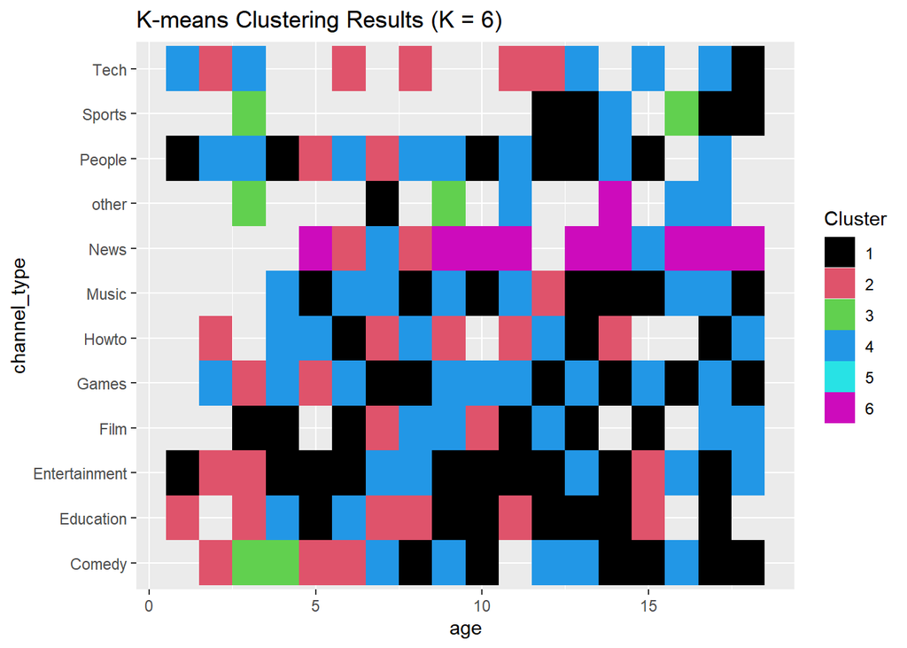

```r
ggplot(kmeans_data, aes(x = age, y = channel_type, fill = Cluster)) +
  geom_tile() +
  scale_fill_manual(values = 1:6) +
  labs(x = "age", y = "channel_type", title = "K-means Clustering Results (K = 6)")
```

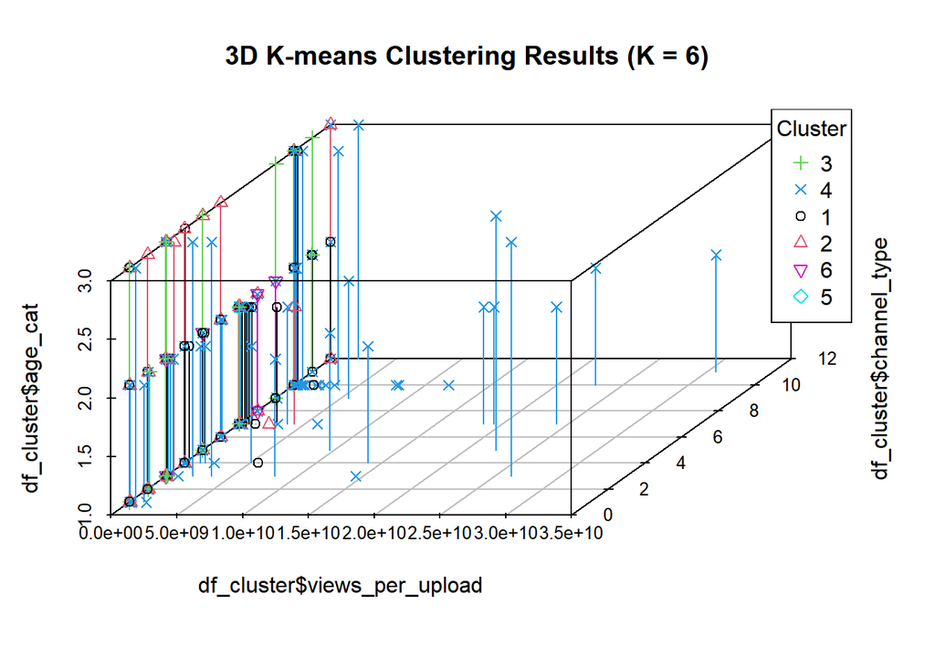

```r
library(scatterplot3d)

# Create a 3D scatterplot with different pch values(shapes) for each cluster
scatterplot3d(df_cluster$views_per_upload, df_cluster$channel_type, df_cluster$age_cat, pch = df_cluster$cluster,
               color = df_cluster$cluster, type = "h", main = "3D K-means Clustering Results (K = 6)")
legend("topright", legend = unique(df_cluster$cluster), title = "Cluster",
       col = unique(df_cluster$cluster), pch = unique(df_cluster$cluster))
```

When we cluster the data using three different dimensions, the clusters are very hard to tell.

We figure the reason could be 1. the raw data itself is very uneven distributed (and when we set numerical data into categorical, the threshold is hard to define) 2.As mentioned in the first chapter, this dataset does have flaw for more precise data analysis, and top 1000 channels have their specificities, when we see interpret all models results, a lot of background knowledge should be involved, not merely focus on numbers and curves.

**Generally speaking,**

**we worked very thoroughly during the whole process, some results are satisfied, and some models still have poor performance. But we achieved the goal we set at first and have building up the interest to go further studying on more machine learning methods.**

# 4. Shiny App

```r
    #### single variable
single_variable <- function(data,variable_name,target_variable) {

  suppressWarnings({
    # lm
    formula <- as.formula(paste(target_variable, "~", variable_name))
    logic_regression <- train(formula, data = data, method = "glm", family = "binomial")

    return(logic_regression)
  })

}

    #### roc

plot_ROC <- function (model, data) {
  pred <- predict(model,newdata = data,type = "prob")
  roc_obj <- roc(data$income_cat, pred[,2])
  plot(roc_obj, col = "red", main = "ROC Curve")
  text(0.6, 0.2, labels = paste("AUC  =", round(auc(roc_obj), 3)), col = "red")
}

plot_ROC_classification <- function (roc_obj1, roc_obj2)  {
  plot(roc_obj1, col = "red", main = "ROC Curve Comparison")
  lines(roc_obj2, col = "blue")


  legend("bottomright", legend = c("Model 1", "*Model 2(improved)"), col = c("red", "blue"), lty = 1)



  text(0.6, 0.2, labels = paste("AUC Model 1 =", round(auc(roc_obj1), 3)), col = "red")
  text(0.6, 0.1, labels = paste("*AUC Model 2 =", round(auc(roc_obj2), 3)), col = "blue")


}

    #### clustering function
get_scaled_df <- function(df, vars_not_to_use) {
  vars_to_scale <- setdiff(names(df), vars_not_to_use)
  scaled_df <- scale(df[, vars_to_scale])
  scaled_df <- as.matrix(scaled_df[complete.cases(scaled_df), ])
  return(scaled_df)
}

get_scaled_center_and_scale <- function(df, vars_not_to_use) {
  vars_to_scale <- setdiff(names(df), vars_not_to_use)
  scaled_df <- scale(df[, vars_to_scale])
  center <- attr(scaled_df, "scaled:center")
  scale <- attr(scaled_df, "scaled:scale")
  return(list(center = center, scale = scale))
}
df_cluster <-data_cleaning_pipeline(data_transformation_pipeline(df))
df_cluster <- na.omit(df_cluster)
vars_not_to_use <- c("Country", "channel_type","age_cat","uploads_freq_cat","lowest_yearly_earnings","highest_yearly_earnings")
scaled_cluster <- get_scaled_df(df_cluster, vars_not_to_use)

performHierarchicalClustering <- function(scaled_cluster, df_cluster, sample_size, num_of_cluster, var) {
  set.seed(123)
  sample_indices <- sample(1:nrow(scaled_cluster), sample_size)
  subset_scaled_cluster <- scaled_cluster[sample_indices, ]
  subset_df_cluster <- df_cluster[sample_indices, ]

  d <- dist(subset_scaled_cluster, method = "euclidean")
  pfit <- hclust(d, method = "ward.D2")
  plot(pfit, labels = subset_df_cluster[[var]], main = "Cluster Dendrogram")
  num_clusters <- num_of_cluster
  rect.hclust(pfit, k = num_clusters)

  clusters <- cutree(pfit, k = num_clusters)

  return(list(pfit, subset_df_cluster))
}

print_clusters <- function(df, groups, cols_to_print) {
  Ngroups <- max(groups)
  for (i in 1:Ngroups) {
    print(paste("cluster", i))
    print(df[groups == i, cols_to_print])
  }
}

# SHINY APP

ui <- fluidPage(theme = shinytheme("cosmo"),

                # In the navbar, we will have 3 tabs
                navbarPage(
                  "youTube channels",

                  # Tab 1: single variable model
                  tabPanel("Single Variable",
                           sidebarPanel(
                             width = 3,
                             selectInput(inputId = "input_single_var",
                                         label = "Choose Variable:",
                                         choices = colnames(train_prepared))
                           ),
                           mainPanel(
                             fluidRow(
                               verbatimTextOutput("sv_output"),
                               br(), br(), br(),
                               plotOutput("sv_roc")
                             )
                           )
                  ),

                  # Tab 2: Classification
                  tabPanel("Logic Regression",


                           mainPanel(
                             fluidRow(
                               verbatimTextOutput("lr_output"),
                               br(), br(), br(),
                               plotOutput("lr_roc", height = "400px", width = "900px")
                             )
                           )
                  ),

                  # Tab 3: Decision Tree
                  tabPanel("Decision Tree",

                           mainPanel(
                             fluidRow(
                               plotOutput("dt_output", height = "400px", width = "900px"),
                               br(), br(), br(),
                               plotOutput("dt_roc", height = "400px", width = "900px")
                             )
                           )
                  ),

                  # Tab 4: Clustering Results
                  tabPanel("Clustering",
                           sidebarPanel(
                               width = 3,
                               selectInput(inputId = "input_cluster_method",
                                                  label = "Choose Method:",
                                                  choices = c("Hierarchical Clustering", "Sample Result","K-Means")),
                               conditionalPanel(
                                 condition = "input.input_cluster_method == 'Sample Result'",
                                 selectInput(inputId = "input_cluster_variable",
                                           label = "Choose Variable:",
                                           choices = c("Country", "channel_type", "age_cat", "uploads_freq_cat", "highest_monthly_earnings")),
                                 selectInput(inputId = "input_sample_size",
                                           label = "Choose Sample Size:",
                                           choices = c(25,50,75,100))),
                               conditionalPanel(
                                 condition = "input.input_cluster_method == 'K-Means'",
                                 selectInput(inputId = "input_variableA",
                                             label = "Choose Variable 1:",
                                             choices = c("Country", "channel_type", "age_cat", "uploads_freq_cat")),
                                 selectInput(inputId = "input_variableB",
                                             label = "Choose Variable 2:",
                                             choices = c("channel_type", "age_cat", "uploads_freq_cat")))
                                  ),
                           mainPanel(
                               width = 9,
                               plotOutput("cluster", height = "800px", width = "800px")
                           )
                  )
))
```

```r
# Define the server
server <- function(input, output, session) {
  options(warn = -1)
  output$sv_output <- renderPrint({

     summary(single_variable(train_prepared, input$input_single_var, "income_cat"))

  })

  output$sv_roc <- renderPlot({
    model <- single_variable(train_prepared, input$input_single_var, "income_cat")
    plot_ROC(model, test_prepared)



  })


  ##tab 2
  output$lr_output <- renderPrint({

    model_2 <- glm(income_cat ~ .,
                   data = perform_feature_engineering(train_data, normalisation = TRUE, selection = 1),
                   family = "binomial")
    summary(model_2)


    })

    output$lr_roc <- renderPlot({


      model_1 <- glm(income_cat ~ .,
                     data = perform_feature_engineering(train_data, normalisation = FALSE, selection = 0),
                     family = "binomial")
      model_2 <- glm(income_cat ~ .,
                     data = perform_feature_engineering(train_data, normalisation = TRUE, selection = 1),
                     family = "binomial")
      predictions1 <- predict(model_1,
                              newdata = perform_feature_engineering(validation_data, normalisation = FALSE, selection = 0),
                              type = "response")



      predictions2 <- predict(model_2,
                              newdata = perform_feature_engineering(validation_data, normalisation = TRUE, selection = 1),
                              type = "response")
      roc_obj_1 <- roc(validation_data$income_cat, predictions1)
      roc_obj_2 <- roc(validation_data$income_cat, predictions2)

      plot_ROC_classification(roc_obj_1, roc_obj_2)


    })









  ##tab 3
  output$dt_output <- renderPlot({



    best_model <- rpart(income_cat ~ .,
                        data = perform_feature_engineering(train_data, normalisation = FALSE, selection = 2),
                        method = "class",
                        control = rpart.control(cp = model_4$bestTune$cp))
    rpart.plot(best_model)


  })

  output$dt_roc <- renderPlot({

    model_3 <- rpart(income_cat ~ .,
                     data = perform_feature_engineering(train_data, normalisation = FALSE, selection = 0),
                     method = "class")
    ctrl <- trainControl(method = "cv", number = 5)


    param_grid <- expand.grid(cp = seq(0.01, 0.15, by = 0.01))

    model_4 <- train(
      income_cat ~ .,
      data = perform_feature_engineering(train_data, normalisation = FALSE, selection = 2),
      method = "rpart",
      trControl = ctrl,
      tuneGrid = param_grid)
    predictions3 <- predict(model_3,
                            newdata = perform_feature_engineering(validation_data, normalisation = FALSE, selection = 0),
                            type = "prob")
    predictions4 <- predict(model_4,
                            newdata = perform_feature_engineering(validation_data, normalisation = FALSE, selection = 2),
                            type = "prob")
    roc_obj3 <- roc(validation_data$income_cat, predictions3[,2])
    roc_obj4 <- roc(validation_data$income_cat, predictions4[,2])
    plot_ROC_classification(roc_obj3, roc_obj4)

  })


  ##tab4
  output$cluster <- renderPlot({
    method <- input$input_cluster_method

    if (method == "Hierarchical Clustering") {
      d <- dist(scaled_cluster, method = "euclidean")
      pfit <- hclust(d, method="ward.D2")
      df_cluster <- na.omit(df_cluster)
      princ <- prcomp(scaled_cluster)  # Principal components of scaled_cluster
      nComp <- 2  # First two principal components
      project2D <- as.data.frame(predict(princ, newdata = scaled_cluster)[, 1:nComp])
      hclust.project2D <- cbind(project2D, cluster = as.factor(cutree(pfit, k=5)), channel = df_cluster$channel_type)
      find_convex_hull <- function(proj2Ddf) {
        do.call(rbind,
                lapply(unique(cutree(pfit, k=5)),
                       FUN = function(c) {
                         f <- subset(proj2Ddf, cluster==c);
                         f[chull(f),]
                       }))}

      hclust.hull <- find_convex_hull(hclust.project2D)

      ggplot(hclust.project2D, aes(x=PC1, y=PC2)) +
        geom_point(aes(shape=cluster, color=cluster)) +
        geom_text(aes(label=channel, color=cluster), hjust=0, vjust=1, size=3) +
        geom_polygon(data=hclust.hull, aes(group=cluster, fill=as.factor(cluster)),
                     alpha=0.4, linetype=0) + theme(text=element_text(size=20))+
        labs(title = "Cluster Analysis of channel_type")+
        theme(text=element_text(size=20))

    } else if (method == "Sample Result") {


      hierarchical_result <- performHierarchicalClustering(scaled_cluster, df_cluster, input$input_sample_size,5,input$input_cluster_variable)
      s_groups <- cutree(hierarchical_result[[1]], k=5)

      print_clusters(hierarchical_result[[2]], s_groups, c("channel_type","age_cat","uploads_freq_cat"))

    } else if (method == "K-Means") {


      kmeans_result <- kmeans(scaled_cluster, centers = 6)
      cluster_assignments <- factor(kmeans_result$cluster)
      df_cluster$cluster <- cluster_assignments
      var_a <- input$input_variableA
      var_b <- input$input_variableB
      kmeans_data <- data.frame(a = df_cluster[[var_a]],
                                b = df_cluster[[var_b]],
                                Cluster = factor(df_cluster$cluster))

      ggplot(kmeans_data, aes(x = a, y = b, fill = Cluster)) +
        geom_tile() +
        scale_fill_manual(values = 1:6) +
        labs(x = input$input_variableA, y = input$input_variableB, title = "K-means Clustering Results (K = 6)")+
        theme(text=element_text(size=20), axis.text.x = element_text(angle = 90, hjust = 1))
    }

  })



}

shinyApp(ui, server)
```

[interactive chart not shown]

# 5. Reference

Betensky, Rebecca A. 2019. “The p-Value Requires Context, Not a Threshold.” *The American Statistician*. https://doi.org/10.1080/00031305.

Irshad, Mohammed Shahid, Adarsh Anand, and Mangey Ram. 2023. “Trending or Not? Predictive Analysis for Youtube Videos.” *International Journal of System Assurance Engineering and Management*. https://doi.org/10.1007/s13198-023-02034-8.

Lupu-Tătaru, D. A., and R. Lixăndroiu. 2022. “YouTube Channels, Subscribers, Uploads and Views: A Multidimensional Analysis of the First 1700 Channels from July 2022.” *Sustainability (Basel, Switzerland)*. https://doi.org/10.3390/su142013112.